# Ordinal Regression

Author

Patrick Torralba

# 1 Setup

## 1.1 Library

```r
library(tidyverse)
library(gtsummary) ## make table 1
library(psych) ## descriptive stats for table 2
library(broom) ## clean object output
library(kableExtra) ## convert object outputs into table
library(stringr)
library(tidymodels)
library(multilevelmod) ## tidymodels extension for proportional_odds
library(latex2exp) ## write latex equations in plots and tables
library(jtools) ## needed for ordinal regression calculation
library(VGAM) ## needed for ordinal regression calculation
```

## 1.2 Load Data

## 1.3 Data Clean

```r
tomhs <- tomhs %>%
  mutate(
    Sex = as.factor(if_else(sex == 1, "Male", "Female")),
    Race = as.factor(case_when(
      race == 1 ~ "White",
      race == 2 ~ "Black",
      race == 3 ~ "Asian",
      race == 4 ~ "Other"
    )),
    Eversmk = as.factor(if_else(eversmk == 1, "Yes", "No")),
    GenHealth = as.factor(case_when(
      ql12_1 == 1 ~ "Excellent",
      ql12_1 == 2 ~ "Very good",
      ql12_1 == 3 ~ "Good",
      ql12_1 == 4 ~ "Fair",
      ql12_1 == 5 ~ "Poor"
    )
    )
  )

tomhs <- tomhs %>%
  mutate(GenHealth = ordered(fct_relevel(GenHealth,
    "Excellent",
    "Very good",
    "Good",
    "Fair",
    "Poor"
  )))
```

# 2 Exploratory Data Analysis

## 2.1 Table 1: Particpant Demographics

```r
tbl_1 <- tomhs %>%
  select(age, Sex, Race, Eversmk, GenHealth) %>%
  tbl_summary(
    by = Eversmk,
    label = list(
      Eversmk = "Ever Smoke",
      age = "Age",
      GenHealth = "General Health"
    )
  ) %>%
  add_overall() %>%
  bold_labels() %>%
  italicize_levels()
```

```
3 missing rows in the "Eversmk" column have been removed.
```

```r
tbl_1
```

Table 1: Participant Demographics by Ever Smoke Status

| **Characteristic** | **Overall** N = 899<sup>1</sup> | **No** N = 479<sup>1</sup> | **Yes** N = 420<sup>1</sup> |
| --- | --- | --- | --- |
| Age | 54 (50, 60) | 54 (50, 59) | 54 (49, 60) |
| Sex |  |  |  |
| Female | 345 (38%) | 222 (46%) | 123 (29%) |
| Male | 554 (62%) | 257 (54%) | 297 (71%) |
| Race |  |  |  |
| Asian | 10 (1.1%) | 7 (1.5%) | 3 (0.7%) |
| Black | 177 (20%) | 88 (18%) | 89 (21%) |
| Other | 6 (0.7%) | 4 (0.8%) | 2 (0.5%) |
| White | 706 (79%) | 380 (79%) | 326 (78%) |
| General Health |  |  |  |
| Excellent | 177 (21%) | 96 (21%) | 81 (21%) |
| Very good | 405 (48%) | 227 (50%) | 178 (46%) |
| Good | 223 (26%) | 109 (24%) | 114 (29%) |
| Fair | 38 (4.5%) | 22 (4.8%) | 16 (4.1%) |
| Poor | 1 (0.1%) | 1 (0.2%) | 0 (0%) |
| Unknown | 55 | 24 | 31 |

<sup>1</sup> Median (Q1, Q3); n (%)

## 2.2 General Health Variable Table

```r
tbl_2 <- tomhs %>%
  select(ql12_1) %>%
  describe(IQR = TRUE) %>%
  as.data.frame() %>%
  select(-trimmed) %>%
  kable(digits = 2,
        col.names = tools::toTitleCase(names(.)),
        align = "c") %>%
  kable_styling(
    bootstrap_options = c("striped","hover","condensed"),
    full_width = FALSE,
    position = "center")

tbl_2
```

Table 2: General Health Variable Summary

|  | Vars | n | Mean | Sd | Median | Mad | Min | Max | Range | Skew | Kurtosis | Se | IQR |
| --- | --- | --- | --- | --- | --- | --- | --- | --- | --- | --- | --- | --- | --- |
| ql12_1 | 1 | 845 | 2.15 | 0.8 | 2 | 1.48 | 1 | 5 | 4 | 0.31 | -0.32 | 0.03 | 1 |

## 2.3 General Health Variable Distribution

Figure 1: General Health Variable Distribution

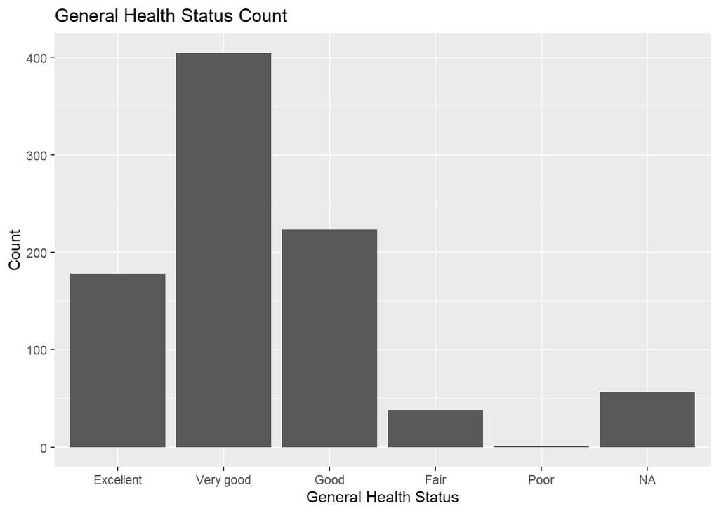

```r
ggplot(tomhs,aes(x = GenHealth)) +
  geom_bar() +
  labs(
    x = "General Health Status",
    y = "Count",
    title = "General Health Status Count"
  )
```

```r
tbl_3 <- tomhs %>%
  select(GenHealth) %>%
  group_by(GenHealth) %>%
  summarize(Count = n()) %>%
  arrange(GenHealth) %>%
  kable(col.names = c("General Health", "Count")) %>%
  kable_styling(
    bootstrap_options = c("striped", "hover", "condensed"),
    full_width = FALSE,
    position = "center"
  )


tbl_3
```

Table 3: General Health Category Count

| General Health | Count |
| --- | --- |
| Excellent | 178 |
| Very good | 405 |
| Good | 223 |
| Fair | 38 |
| Poor | 1 |
| NA | 57 |

## 2.4 Relationship between General Health and Ever Smoke

Figure 2: General Health by Ever Smoke Status

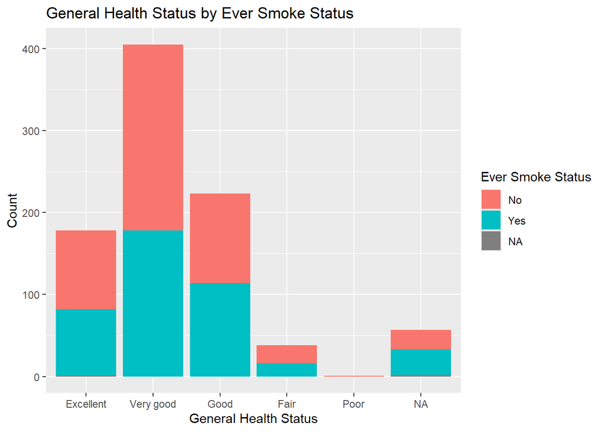

```r
ggplot(tomhs, aes(x = GenHealth, fill = Eversmk)) +
  geom_bar() +
  labs(
    x = "General Health Status",
    y = "Count",
    fill = "Ever Smoke Status",
    title = "General Health Status by Ever Smoke Status"
  )
```

# 3 Model 3: Adjusted Ordinal Regression

## 3.2 Ordinal Regression Model: The effect of eversmk on ql12_1 after adjusting for age

```r
model_1 <- vglm(
                formula = GenHealth ~ Eversmk + age,
                data = tomhs,
                family = cumulative(link = "logitlink", parallel = TRUE))

model_1
```

```
Call:
vglm(formula = GenHealth ~ Eversmk + age, family = cumulative(link = "logitlink",
    parallel = TRUE), data = tomhs)


Coefficients:
(Intercept):1 (Intercept):2 (Intercept):3 (Intercept):4    EversmkYes
  -0.43061050    1.69901761    3.93349377    7.64542721   -0.10852492
          age
  -0.01551486

Degrees of Freedom: 3376 Total; 3370 Residual
Residual deviance: 1987.3
Log-likelihood: -993.6501
```

```r
model_1 %>%  ## log form
  tbl_regression(
    intercept = TRUE,
    exponentiate = FALSE
    ) %>%
  bold_labels() %>%
  italicize_levels()
```

Table 4: Results: The Effect of Smoking on General Health after Adjusting for Age [log]

| **Characteristic** | **log(OR)** | **95% CI** | **p-value** |
| --- | --- | --- | --- |
| logitlink(P[Y<=1]) |  |  |  |
| (Intercept) | -0.43 | -1.5, 0.66 | 0.4 |
| logitlink(P[Y<=2]) |  |  |  |
| (Intercept) | 1.7 | 0.60, 2.8 | 0.002 |
| logitlink(P[Y<=3]) |  |  |  |
| (Intercept) | 3.9 | 2.8, 5.1 | <0.001 |
| logitlink(P[Y<=4]) |  |  |  |
| (Intercept) | 7.6 | 5.4, 9.9 | <0.001 |
| parallel |  |  |  |
| Eversmk |  |  |  |
| No | — | — |  |
| Yes | -0.11 | -0.36, 0.14 | 0.4 |
| age | -0.02 | -0.04, 0.00 | 0.12 |

Abbreviations: CI = Confidence Interval, OR = Odds Ratio

```r
model_1 %>%  ## exponent form
  tbl_regression(
    intercept = TRUE,
    exponentiate = TRUE,
    ) %>%
  bold_labels() %>%
  italicize_levels()
```

Table 5: Results: The Effect of Smoking on General Health after Adjusting for Age [exponent]

| **Characteristic** | **OR** | **95% CI** | **p-value** |
| --- | --- | --- | --- |
| logitlink(P[Y<=1]) |  |  |  |
| (Intercept) | 0.65 | 0.22, 1.93 | 0.4 |
| logitlink(P[Y<=2]) |  |  |  |
| (Intercept) | 5.47 | 1.83, 16.4 | 0.002 |
| logitlink(P[Y<=3]) |  |  |  |
| (Intercept) | 51.1 | 16.4, 159 | <0.001 |
| logitlink(P[Y<=4]) |  |  |  |
| (Intercept) | 2,091 | 221, 19,747 | <0.001 |
| parallel |  |  |  |
| Eversmk |  |  |  |
| No | — | — |  |
| Yes | 0.90 | 0.70, 1.16 | 0.4 |
| age | 0.98 | 0.97, 1.00 | 0.12 |

Abbreviations: CI = Confidence Interval, OR = Odds Ratio

### 3.2.1 Ordinal Regression Model Interpretation

- Using the model results, what is the estimated common odds ratio for the eversmk variable? Provide an interpretation of this common odds ratio in the context of the problem.
  - The estimated common odds-ratio for the eversmk variable is 0.90. This means patients who smoke have a 10% decrease in odds of reporting a better health status (e.g “Excellent”).
- Using the model results, is there a significant relationship between having ever smoked cigarettes and general health at 12 months, after adjusting for age? Explain your reasoning.
  - No, after adjusting for age, we conclude that there is not a statistically significant relationship between having ever smoked cigarettes and general health at 12 months considering that the p-value is greater than alpha and the confidence interval includes 1.0 (OR = 0.90, p-value = 0.4, CI: 0.70 to 1.16).
- Using the model results, what is the estimated common odds ratio for the age variable? Provide an interpretation of this common odds ratio in the context of the problem.
  - The estimated common-odds ratio for the age variable is 0.98. This indicates that for every one-year increase in age, the odds of a patient reporting a better general health status (e.g., ‘Excellent’ vs. all lower categories) decrease by 2%, holding smoking status constant.
- Using the model results, is there a significant relationship between age and general health at 12 months, after adjusting for having ever smoked cigarettes? Explain your reasoning.
  - After adjusting for having ever smoked cigarettes, we conclude that the relationship between age and general health at 12 months is not statistically significant given that the p-value is greater than alpha and the confidence interval includes 1.0 (p-value = 0.12, CI: 0.97 to 1.00).

# 4 Ordinal Regression Summary Notes

1. Data Cleaning tips
   1. Make sure to set your categorical variable into an ordered factor
      1. This is super important for generating the model
   2. Section 1.3
2. How do I write the fitted equation?
   1. Make sure to write the fitted equation **ONLY IN LOG FORM**
   2. Section 3.1
3. How do I generate an ordinal regression model?
   1. Section 3.2
4. How do I interpret the output?
   1. Make sure to interpret the output **ONLY IN EXPONENT FORM**
   2. Make sure to also state “a X% increase/decrease in the odds” instead of “more/less likely”
      1. Remember. When we are dealing with odds-ratios we must not use probability vocab
   3. Section 3.2.1
5. I don’t understand. What does “logitlink(P[Y<=1])” mean in the table output?
   1. This represents the order of the categorical variable
      1. In this scenario, 1 represents Excellent, 2 represents Very Good.
      2. This all depends on how you ordered your factored categorical variable
   2. Section 3.2